# Activity Monitoring Analysis

Miguel Gutierrez

19 de noviembre de 2020

## Summary

This device collects data at 5 minute intervals through out the day. The data consists of two months of data from an anonymous individual collected during the months of October and November, 2012 and include the number of steps taken in 5 minute intervals each day. There are a total of 17,568 observations in this dataset. In this work, the activity data was evaluated according to the variable steps and time intervals. The missing values are coded as "NA" and and then the missing data were filled in with the averages of the 5-minute intervals from the database.

### Objectives

1. What is mean total number of steps taken per day?
2. What is the average daily activity pattern?
3. Imputing missing values
4. Are there differences in activity patterns between weekdays and weekends?

### Loading and preprocessing the data

```r
# Load and explore
head(data1)
```

```
##   steps       date interval
## 1    NA 2012-10-01        0
## 2    NA 2012-10-01        5
## 3    NA 2012-10-01       10
## 4    NA 2012-10-01       15
## 5    NA 2012-10-01       20
## 6    NA 2012-10-01       25
```

```r
# View summary of data
summary(data1)
```

```
##      steps             date               interval
##  Min.   :  0.00   Min.   :2012-10-01   Min.   :   0.0
##  1st Qu.:  0.00   1st Qu.:2012-10-16   1st Qu.: 588.8
##  Median :  0.00   Median :2012-10-31   Median :1177.5
##  Mean   : 37.38   Mean   :2012-10-31   Mean   :1177.5
##  3rd Qu.: 12.00   3rd Qu.:2012-11-15   3rd Qu.:1766.2
##  Max.   :806.00   Max.   :2012-11-30   Max.   :2355.0
##  NA's   :2304
```

The variables shown in this dataset are:

**steps**: Number of steps taking in a 5-minute interval (missing values are coded as "NA"). **date**: The date on which the measurement was taken in YYYY-MM-DD format. **interval**: Identifies for the 5-minute interval in which measurement was taken

### 1. What is mean total number of steps taken per day?

#### 1.1 Total number of steps taken per day

```r
# Creating the data of steps per day
stepsxDay <- aggregate(steps ~ date, data1, FUN = sum, na.rm=TRUE)
head(stepsxDay)
```

```
##         date steps
## 1 2012-10-02   126
## 2 2012-10-03 11352
## 3 2012-10-04 12116
## 4 2012-10-05 13294
## 5 2012-10-06 15420
## 6 2012-10-07 11015
```

#### 1.2 Histogram of the total number of steps taken each day

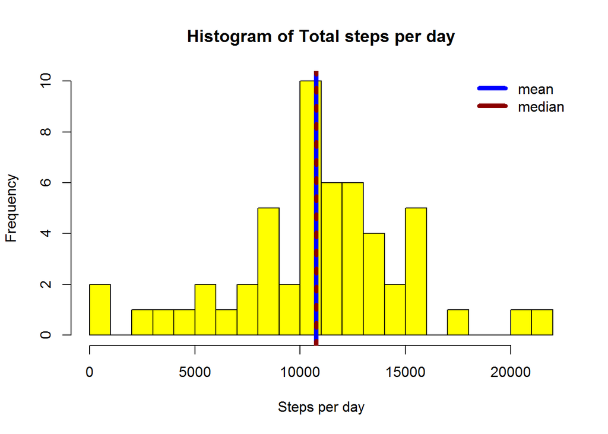

```r
hist(stepsxDay$steps, xlab = "Steps per day", breaks = 20, main = "Histogram of Total steps per day", col = "yellow")
abline(v=mean(stepsxDay$steps),col="blue",lwd=5)
abline(v=median(stepsxDay$steps),lty = "dotted", col="darkred",lwd=5)
legend("topright", legend = c("mean","median"), col=c("blue","darkred"), lwd=5,bty = "n")
```

#### 1.3 The mean and median of the total number of steps taken per day

```
## mean of total steps per day : 10766.19
```

```
## median of total steps per day : 10765
```

### 2. What is the average daily activity pattern?

#### 2.1 Time series plot of interval and the average number of steps taken, averaged across all days (y-axis)

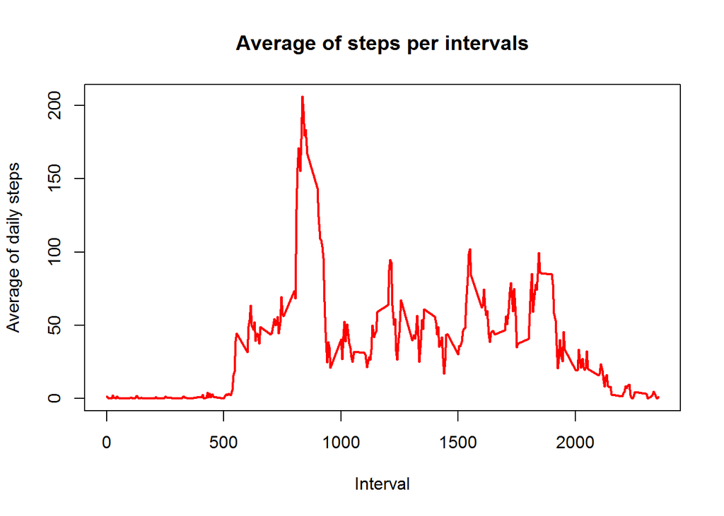

```r
# Creating data of mean steps per time interval
average_day <- aggregate(steps ~ interval, data1, FUN = mean, na.rm=TRUE)
# Scatterplot of 5-minutes interval vs steps
plot(x = average_day$interval, y = average_day$steps, type = "l", col="red", lwd = 2, xlab = "Interval", ylab="Average of daily steps", main="Average of steps per intervals")
```

#### 2.2 Which interval, on average across all the days in the dataset, contains the maximum number of steps?

```
## the 5-minute interval that contains the maximum number of steps is  835 th interval
```

the 5-minute interval that contains the maximum number of steps is the 835 th interval.

### 3. Imputing missing values

#### 3.1 The total number of missing values in the dataset

```
## the total number of missing values in the dataset : 2304
```

#### 3.2 Strategy for filling in all of the missing values in the dataset.

The strategy is to identify the missing data and fill in the data averages steps by intervals.

#### 3.3 New dataset with the missing data filled in.

```r
imputed_steps <- average_day$step[match(data1$interval, average_day$interval)]
# Missing data filled in
imputed_data1 <- transform(data1, steps = ifelse(is.na(data1$steps), yes = imputed_steps, no = data1$steps))
# Review Original data (with NAs)
head(data1, 4)
```

```
##   steps       date interval
## 1    NA 2012-10-01        0
## 2    NA 2012-10-01        5
## 3    NA 2012-10-01       10
## 4    NA 2012-10-01       15
```

```r
# Review about Original data with the missing data filled in
head(imputed_data1,4)
```

```
##       steps       date interval
## 1 1.7169811 2012-10-01        0
## 2 0.3396226 2012-10-01        5
## 3 0.1320755 2012-10-01       10
## 4 0.1509434 2012-10-01       15
```

#### 3.4 Histogram of the total number of steps taken each day

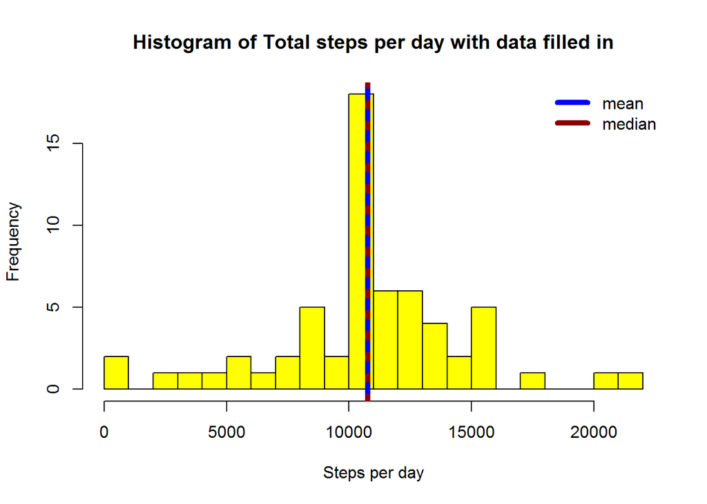

#### 3.5 The mean and median total number of steps taken per day.

```
## mean of total steps per day with data filled in : 10766.19
```

```
## median of total steps per day with data filled in: 10766.19
```

#### 3.6 Do these values differ from the estimates from the first part of the assignment? What is the impact of imputing missing data on the estimates of the total daily number of steps?

**Answer:** Yes, the impact of filled in 0%, in the case of the median the impact of the data filled in is 0.0110421%. With these results we have that the mean and the median have not changed, but the histogram of the filled data shows higher density around the mean / median with respect to the original data.

### 4. Are there differences in activity patterns between weekdays and weekends?

#### 4.1 Creating a new factor variable in the dataset with two levels - "weekday" and "weekend" indicating whether a given date is a weekday or weekend day.

```r
# Including weekday data
imputed_data1$weekday <- weekdays(imputed_data1$date)
head(imputed_data1)
```

```
##       steps       date interval weekday
## 1 1.7169811 2012-10-01        0   lunes
## 2 0.3396226 2012-10-01        5   lunes
## 3 0.1320755 2012-10-01       10   lunes
## 4 0.1509434 2012-10-01       15   lunes
## 5 0.0754717 2012-10-01       20   lunes
## 6 2.0943396 2012-10-01       25   lunes
```

```r
# Labeling Sabado (Saturday) or Domingo (Sunday) as "weekend"
imputed_data1$datetype <- ifelse(imputed_data1$weekday=='sabado' | imputed_data1$weekday=='domingo', 'weekend','weekday')
head(imputed_data1)
```

```
##       steps       date interval weekday datetype
## 1 1.7169811 2012-10-01        0   lunes  weekday
## 2 0.3396226 2012-10-01        5   lunes  weekday
## 3 0.1320755 2012-10-01       10   lunes  weekday
## 4 0.1509434 2012-10-01       15   lunes  weekday
## 5 0.0754717 2012-10-01       20   lunes  weekday
## 6 2.0943396 2012-10-01       25   lunes  weekday
```

#### 4.2 Making a panel plot containing a time series plot of the 5-minute interval (x-axis) and the average number of steps taken, averaged across all weekday days or weekend days (y-axis).

```r
library(ggplot2)
data1_date <- aggregate(steps~interval + datetype, imputed_data1, mean, na.rm = TRUE)
head(data1_date)
```

```
##   interval datetype      steps
## 1        0  weekday 1.94375222
## 2        5  weekday 0.38447846
## 3       10  weekday 0.14951940
## 4       15  weekday 0.17087932
## 5       20  weekday 0.08543966
## 6       25  weekday 1.38981844
```

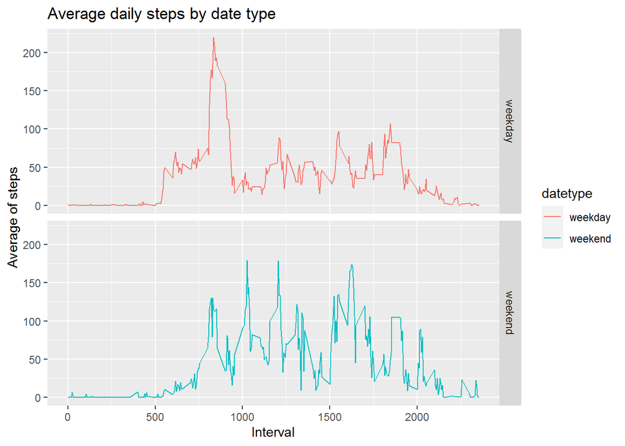

```r
p <- ggplot(data1_date, aes(x = interval , y = steps, color = datetype)) +
       geom_line() +
       labs(title = "Average daily steps by date type", x = "Interval", y = "Average of steps") +
       facet_grid(datetype~.)
print(p)
```